# BIOL 3100 Final Project Effects of maternal stress and gut microbiome on offspring social behaviors in long-bout stress

# Project background

Acute and chronic social stress effects individuals of many species. The effects of long bouts of social stress on physiology and social behavior can differ among individuals, but what factors cause these individual differences is less clear. Manipulations to the maternal microbiome and maternal stress can have sex-specific effects on offspring social behaviors and may help explain variation in behavioral responses to prolonged stress. To test this, we investigated how maternal environment affects differences in offspring social behavior during long-bout stress in Siberian hamsters (*Phodopus sungorus*, figure 1). Pregnant females were exposed to one of four treatments (social stress, microbiome manipulation, both, or no treatment) for ten days. Adolescent offspring were exposed to a same-sex intruder for 15 minutes to assess behavioral responses to long bouts of social stress. We compared differences in the frequency and duration of offspring aggression, investigation, and escape behaviors during the first and last five minutes of the resident-intruder trial.

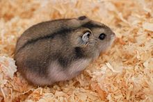

**Figure 1.** Image of Siberian hamster *Phodopus sungorus*. Image attribution: Salzgeber, P. (2007). Phodopus sungorus. In Wikimedia Commons. https://commons.wikimedia.org/wiki/File:PhodopusSungorus_1.jpg

# Data collection and preparation

Data collection occurred in Dec 2019 in the Demas Lab at Indiana University. Offspring behaviors during the first five minutes of the trial (t0-t5) were scored by JAC in the following few weeks. In Spring 2023, TCB scored offspring behaviors from the last five minutes (t10-t15). After data collection, the data needed to be cleaned and prepared for statistical analyses.

## Data cleaning

Below is the code used to clean the and prepare the data for analyses. Several columns were removed from the data frame because they were not used in this project (these were columns imported into the excel sheet from the original project in 2019).

```r
# Load data, clean names, view structure ####
hammies <- read_csv("../final_project/IU106_Social Behavior First and Last Five Minutes_Formatted_6-6-23.csv")
hammies <- janitor::clean_names(hammies)
names(hammies)
str(hammies)

# Remove columns that were not used in this project ####
columns_removed <- c("id", "aggression_number_assigned", "comp1", "comp2", "comp3",
                     "aggression_score_freq", "aggression_score_duration")
hammies <- dplyr::select(hammies, -columns_removed)

# Create trial timing column, set appropriate columns as factors ####
tidy_hammies <- hammies %>%
  mutate(trial_timing = as.factor(first_or_last_five_minutes)) %>%
  mutate(treatment = as.factor(maternal_treatment)) %>%
  mutate(juvenile_id = as.factor(juvenile_id)) %>%
  dplyr::select(-first_or_last_five_minutes)

# Fix spelling of all "occurence" columns ####
tidy_hammies <- tidy_hammies %>%
  mutate(attack_number_of_occurrences = attack_number_of_occurences) %>%
  mutate(chase_number_of_occurrences = chase_number_of_occurences) %>%
  mutate(groom_number_of_occurrences = groom_number_of_occurences) %>%
  mutate(investigation_number_of_occurrences = investigation_number_of_occurences) %>%
  mutate(jump_number_of_occurrences = jump_number_of_occurences) %>%
  dplyr::select(-contains("occurences"))

str(tidy_hammies)
```

## Modeling Juvenile Behavior

We analyzed the number (i.e., frequency) and total duration of behavioral bouts in the first and last five minutes (t0-t5 vs. t10-t15). For each model, we first tested for a three-way interaction between maternal treatment, offspring sex, and trial timing. If no significant three-way interaction was detected, we tested for a two-way interaction between offspring sex and maternal treatment. Only significant interactions were retained in the model; non-significant interaction terms were removed.

### Summary of models

All models had two random effects: intruder identity and resident (offspring) identity, to control for individual differences in behavior. All frequency models (GLMM’s) used the bobyqa optimizer from the lme4 package for model fitting.

**Table 1.** Summary of models run for each response variable.

| Response Variable | Distribution | Fixed Effects |
| --- | --- | --- |
| Attack Frequency | Poisson, Log link function | Offspring sex, maternal treatment, trial timing, SI- CORT, offspring weight, offspring sex*maternal treatment interaction |
| Attack Duration | Gaussian, Identity link function | Offspring sex, maternal treatment, trial timing, SI-CORT, offspring weight |
| Investigation Frequency | Poisson, Log link function | Offspring sex, maternal treatment, trial timing, SI-CORT, offspring weight, offspring sex*maternal treatment*trial timing |
| Investigation Duration | Gaussian, Identity link function | Offspring sex, maternal treatment, trial timing, SI-CORT, offspring weight |
| Escape Frequency | Poisson, Log link function | Offspring sex, maternal treatment, trial timing, SI-CORT, offspring weight, offspring sex*maternal treatment*trial timing |
| Escape Duration | Gaussian, Identity link function | Offspring sex, maternal treatment, trial timing, SI-CORT, offspring weight |
| Grooming Frequency | Poisson, Log link function | Offspring sex, maternal treatment, trial timing, SI-CORT, offspring weight |
| Grooming Duration | Gaussian, Identity link function | Offspring sex, maternal treatment, trial timing, SI-CORT, offspring weight, offspring sex* maternal treatment |

# Agression frequency

## Results

Our first model analyzes the effects of maternal treatment, offspring sex, and video timing on the frequency of aggressive behaviors. There was no significant three-way interaction, but we did detect a significant interaction between maternal treatment and offspring sex. Below is the code for model 1.

```r
modelA.1 <- tidy_hammies %>%
  glmer(attack_number_of_occurrences ~ sex*treatment+trial_timing+scale(si_cort)
        +weight_at_trial+(1|intruder_id)+(1|juvenile_id),family=poisson,
        glmerControl(optimizer="bobyqa"),data=.)
```

```r
broom.mixed::tidy(modelA.1) %>%
  kable("pipe", digits = 3, caption = "**Table 2.** Summary of model A.1, analyzing the interactive effects of maternal treatment and offspring sex on frequency of attack behaviors in the first and last five minutes of the resident-intruder trial.") %>%
  kable_styling() %>%
  kableExtra::row_spec(.,c(4:6, 10), bold=TRUE) %>%
  kableExtra::column_spec(column = 1:7, width = "200px")
```

**Table 2.** Summary of model A.1, analyzing the interactive effects of maternal treatment and offspring sex on frequency of attack behaviors in the first and last five minutes of the resident-intruder trial.

| effect | group | term | estimate | std.error | statistic | p.value |
| --- | --- | --- | --- | --- | --- | --- |
| fixed | NA | (Intercept) | 0.589 | 0.706 | 0.834 | 0.404 |
| fixed | NA | sexMale | 0.430 | 0.373 | 1.153 | 0.249 |
| fixed | NA | treatmentAntibiotic Only | 0.604 | 0.388 | 1.555 | 0.120 |
| fixed | NA | treatmentControl | -2.299 | 1.050 | -2.190 | 0.029 |
| fixed | NA | treatmentStress Only | 0.852 | 0.384 | 2.221 | 0.026 |
| fixed | NA | trial_timingLast | -0.321 | 0.153 | -2.103 | 0.035 |
| fixed | NA | scale(si_cort) | 0.023 | 0.101 | 0.228 | 0.819 |
| fixed | NA | weight_at_trial | 0.014 | 0.022 | 0.645 | 0.519 |
| fixed | NA | sexMale:treatmentAntibiotic Only | -0.551 | 0.485 | -1.137 | 0.256 |
| fixed | NA | sexMale:treatmentControl | 2.323 | 1.106 | 2.101 | 0.036 |
| fixed | NA | sexMale:treatmentStress Only | -0.784 | 0.482 | -1.626 | 0.104 |
| ran_pars | juvenile_id | sd__(Intercept) | 0.145 | NA | NA | NA |
| ran_pars | intruder_id | sd__(Intercept) | 0.000 | NA | NA | NA |

This is a poisson mixed model fitted to predict number of attack bouts.

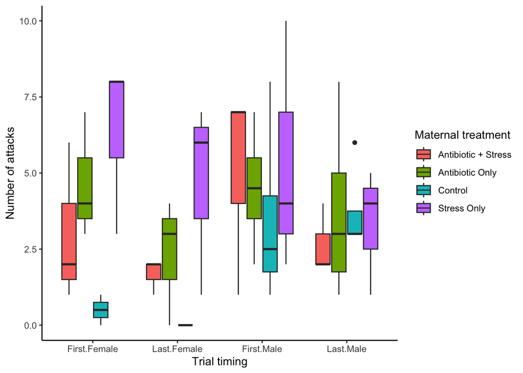

**Figure 2.** Plot of aggression frequency by sex and trial timing.

```r
tidy_hammies %>%
  ggplot(aes(x=interaction(trial_timing, sex),
             y = attack_number_of_occurrences))+
  geom_boxplot(aes(fill=treatment))+
  labs(x= "Trial timing",
       y = "Number of attacks",
       fill = "Maternal treatment")+
  theme(axis.line = element_line(color="black"),
        panel.grid.major = element_blank(),
        panel.grid.minor = element_blank(),
        panel.background = element_blank())
```

We then used the lsmeans function from the emmeans R package to conduct pairwise comparisons of the maternal treatment and sex interactions. lsmeans uses a corrected p-value since to minimize the likelihood of a type I error, since we are performing a large number of comparisons. After running the lsmeans, none of our pairwise comparisons are statistically significant using a p-value of 0.05.

```r
#pairwise comparisons with corrected p-value
lsmeans(modelA.1, pairwise~treatment, type = "response") # because there was a significant 2-way interaction, we are more interested in the interaction below.
lsmeans(modelA.1, pairwise~treatment*sex, type = "response")
```

```r
lsmeans_output <- lsmeans(modelA.1, pairwise~treatment*sex, type = "response")
lsmeans_contrasts <- lsmeans_output$contrasts
lsmeans_contrasts_df <- as.data.frame(lsmeans_contrasts)
lsmeans_contrasts_df %>%
  kable("pipe", digits = 3, caption = "**Table 3.** lsmeans comparisons for attack frequency.") %>%
  kable_styling() %>%
  kableExtra::row_spec(.,14, bold=TRUE) %>%
  kableExtra::column_spec(column = 1:7, width = "200px")
```

**Table 3.** lsmeans comparisons for attack frequency.

| contrast | estimate | SE | df | null | z.ratio | p.value |
| --- | --- | --- | --- | --- | --- | --- |
| (Antibiotic + Stress Female) / Antibiotic Only Female | 0.547 | 0.212 | Inf | 1 | -1.555 | 0.777 |
| (Antibiotic + Stress Female) / Control Female | 9.964 | 10.463 | Inf | 1 | 2.190 | 0.358 |
| (Antibiotic + Stress Female) / Stress Only Female | 0.427 | 0.164 | Inf | 1 | -2.221 | 0.339 |
| (Antibiotic + Stress Female) / (Antibiotic + Stress Male) | 0.651 | 0.243 | Inf | 1 | -1.153 | 0.945 |
| (Antibiotic + Stress Female) / Antibiotic Only Male | 0.617 | 0.217 | Inf | 1 | -1.370 | 0.871 |
| (Antibiotic + Stress Female) / Control Male | 0.635 | 0.219 | Inf | 1 | -1.316 | 0.893 |
| (Antibiotic + Stress Female) / Stress Only Male | 0.608 | 0.231 | Inf | 1 | -1.307 | 0.897 |
| Antibiotic Only Female / Control Female | 18.225 | 19.168 | Inf | 1 | 2.760 | 0.105 |
| Antibiotic Only Female / Stress Only Female | 0.780 | 0.273 | Inf | 1 | -0.710 | 0.997 |
| Antibiotic Only Female / (Antibiotic + Stress Male) | 1.190 | 0.445 | Inf | 1 | 0.465 | 1.000 |
| Antibiotic Only Female / Antibiotic Only Male | 1.129 | 0.389 | Inf | 1 | 0.352 | 1.000 |
| Antibiotic Only Female / Control Male | 1.161 | 0.395 | Inf | 1 | 0.440 | 1.000 |
| Antibiotic Only Female / Stress Only Male | 1.112 | 0.418 | Inf | 1 | 0.282 | 1.000 |
| Control Female / Stress Only Female | 0.043 | 0.045 | Inf | 1 | -2.975 | 0.059 |
| Control Female / (Antibiotic + Stress Male) | 0.065 | 0.067 | Inf | 1 | -2.648 | 0.139 |
| Control Female / Antibiotic Only Male | 0.062 | 0.064 | Inf | 1 | -2.709 | 0.120 |
| Control Female / Control Male | 0.064 | 0.066 | Inf | 1 | -2.672 | 0.131 |
| Control Female / Stress Only Male | 0.061 | 0.063 | Inf | 1 | -2.709 | 0.120 |
| Stress Only Female / (Antibiotic + Stress Male) | 1.525 | 0.588 | Inf | 1 | 1.095 | 0.958 |
| Stress Only Female / Antibiotic Only Male | 1.447 | 0.485 | Inf | 1 | 1.103 | 0.956 |
| Stress Only Female / Control Male | 1.489 | 0.513 | Inf | 1 | 1.155 | 0.944 |
| Stress Only Female / Stress Only Male | 1.425 | 0.529 | Inf | 1 | 0.955 | 0.980 |
| (Antibiotic + Stress Male) / Antibiotic Only Male | 0.949 | 0.285 | Inf | 1 | -0.176 | 1.000 |
| (Antibiotic + Stress Male) / Control Male | 0.976 | 0.308 | Inf | 1 | -0.077 | 1.000 |
| (Antibiotic + Stress Male) / Stress Only Male | 0.935 | 0.299 | Inf | 1 | -0.212 | 1.000 |
| Antibiotic Only Male / Control Male | 1.029 | 0.307 | Inf | 1 | 0.096 | 1.000 |
| Antibiotic Only Male / Stress Only Male | 0.985 | 0.284 | Inf | 1 | -0.052 | 1.000 |
| Control Male / Stress Only Male | 0.958 | 0.317 | Inf | 1 | -0.131 | 1.000 |

## Model assumptions and validation

Below is the code my PI initially used to check model assumptions and check for overdispersion.

```r
# * * Checking model assumptions ------------------------------------------
qqnorm(residuals(modelA.1))
qqline(residuals(modelA.1))
shapiro.test(residuals(modelA.1))


# * * Check overdispersion ------------------------------------------------
overdisp_fun <- function(modelA.1) {
  rdf <- df.residual(modelA.1)
  rp <- residuals(modelA.1,type="pearson")
  Pearson.chisq <- sum(rp^2)
  prat <- Pearson.chisq/rdf
  pval <- pchisq(Pearson.chisq, df=rdf, lower.tail=FALSE)
  c(chisq=Pearson.chisq,ratio=prat,rdf=rdf,p=pval)
}
overdisp_fun
overdisp_fun(modelA.1)

sum(residuals(modelA.1,type="pearson")^2)/(nrow(tidy_hammies)-length(fixef(modelA.1)-1))

vif(modelA.1)
```

Using the performance package we learned about in class, I simplified the overdispersion code, and used check_model to visualize vif and overdispersion.

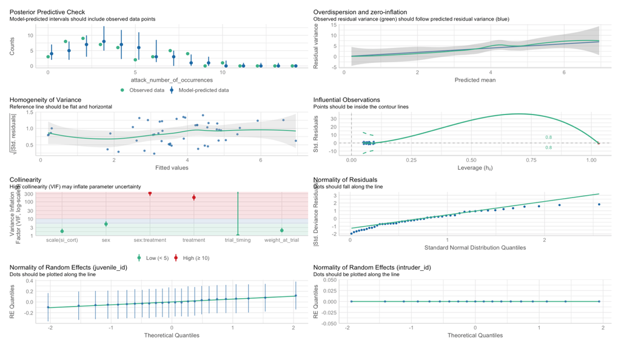

```r
check_model(modelA.1)
```

```r
performance::check_overdispersion(modelA.1)
```

```
## # Overdispersion test
##
##        dispersion ratio =  1.341
##   Pearson's Chi-Squared = 46.932
##                 p-value =  0.086
```

# Aggression Duration

We fitted a linear mixed model for the duration of attack behaviors in the first and last five minutes of the resident-intruder trial. The data were square-root transformed to assume a normal distribution. There were no significant interactions to predict attack behavior duration.

```r
modelA.2 <- lmer(sqrt(attack_total_duration)~ sex+treatment+trial_timing+
                   scale(si_cort)+weight_at_trial+(1|intruder_id)+(1|juvenile_id),
                 data = tidy_hammies)
#summary(modelA.2)
broom.mixed::tidy(modelA.2) %>%
  kable("pipe", digits = 3) %>%
  kable_styling() %>%
  kableExtra::column_spec(column = 1:7, width = "200px")
```

| effect | group | term | estimate | std.error | statistic | df | p.value |
| --- | --- | --- | --- | --- | --- | --- | --- |
| fixed | NA | (Intercept) | 3.608 | 1.390 | 2.597 | 17.398 | 0.019 |
| fixed | NA | sexMale | 0.749 | 0.452 | 1.656 | 17.000 | 0.116 |
| fixed | NA | treatmentAntibiotic Only | 0.324 | 0.600 | 0.540 | 17.000 | 0.596 |
| fixed | NA | treatmentControl | -0.256 | 0.586 | -0.437 | 17.000 | 0.668 |
| fixed | NA | treatmentStress Only | 0.397 | 0.631 | 0.630 | 17.000 | 0.537 |
| fixed | NA | trial_timingLast | -0.009 | 0.299 | -0.031 | 23.000 | 0.976 |
| fixed | NA | scale(si_cort) | 0.180 | 0.251 | 0.717 | 17.000 | 0.483 |
| fixed | NA | weight_at_trial | -0.069 | 0.043 | -1.584 | 17.000 | 0.132 |
| ran_pars | juvenile_id | sd__(Intercept) | 0.677 | NA | NA | NA | NA |
| ran_pars | intruder_id | sd__(Intercept) | 0.000 | NA | NA | NA | NA |
| ran_pars | Residual | sd__Observation | 1.034 | NA | NA | NA | NA |